# Untitled

# if first session on Ucloud

# load data

```r
# check data
d <- read_csv("/work/50114/MAG/data/modeling/psych_replication_matched.csv") %>%
  mutate(log_teamsize = log(n_authors),
         condition_coded = ifelse(condition == "experiment", 1, 0),
         condition_fct = as_factor(condition),
         teamsize_scaled = (n_authors-min(n_authors))/(max(n_authors)-min(n_authors)),
         days_after_2010_scaled = days_after_2010/max(days_after_2010),
         id_fct = as_factor(PaperId)) %>% # because min = 0
  glimpse()
```

```
## Rows: 744
## Columns: 12
## $ match_group            <dbl> 1, 1, 2, 2, 3, 3, 4, 5, 6, 7, 7, 8, 8, 9, 9, 10…
## $ condition              <chr> "experiment", "control", "experiment", "control…
## $ n_authors              <dbl> 5, 5, 1, 1, 11, 11, 2, 2, 2, 4, 4, 4, 4, 6, 6, …
## $ PaperId                <dbl> 2134174525, 1490919247, 2395494269, 2007726610,…
## $ days_after_2010        <dbl> 0, 0, 0, 0, 0, 0, 0, 0, 0, 0, 0, 3, 3, 31, 31, …
## $ c_5                    <dbl> 0, 0, 0, 0, 10, 0, 6, 0, 6, 2, 133, 0, 28, 65, …
## $ log_teamsize           <dbl> 1.6094379, 1.6094379, 0.0000000, 0.0000000, 2.3…
## $ condition_coded        <dbl> 1, 0, 1, 0, 1, 0, 1, 1, 1, 0, 1, 0, 1, 1, 0, 1,…
## $ condition_fct          <fct> experiment, control, experiment, control, exper…
## $ teamsize_scaled        <dbl> 0.08, 0.08, 0.00, 0.00, 0.20, 0.20, 0.02, 0.02,…
## $ days_after_2010_scaled <dbl> 0.000000000, 0.000000000, 0.000000000, 0.000000…
## $ id_fct                 <fct> 2134174525, 1490919247, 2395494269, 2007726610,…
```

# read models (from fit_likelihood.Rmd)

```r
zip_prior <- readRDS("/work/50114/MAG/modeling/models/zip_prior.rds")
zip_post <- readRDS("/work/50114/MAG/modeling/models/zip_post.rds")
negbin_prior <- readRDS("/work/50114/MAG/modeling/models/negbin_prior.rds")
negbin_post <- readRDS("/work/50114/MAG/modeling/models/negbin_post.rds")
zinegbin_prior <- readRDS("/work/50114/MAG/modeling/models/zinegbin_prior.rds")
zinegbin_post <- readRDS("/work/50114/MAG/modeling/models/zinegbin_post.rds")
```

# prior predictive checks

```r
prior_check <- function(model, ndraws, title, xmax){

  pp_check(model,
           ndraws = ndraws) +
    labs(title = title) +
    theme_minimal() +
    xlim(0, xmax)

}
```

## ZIP prior

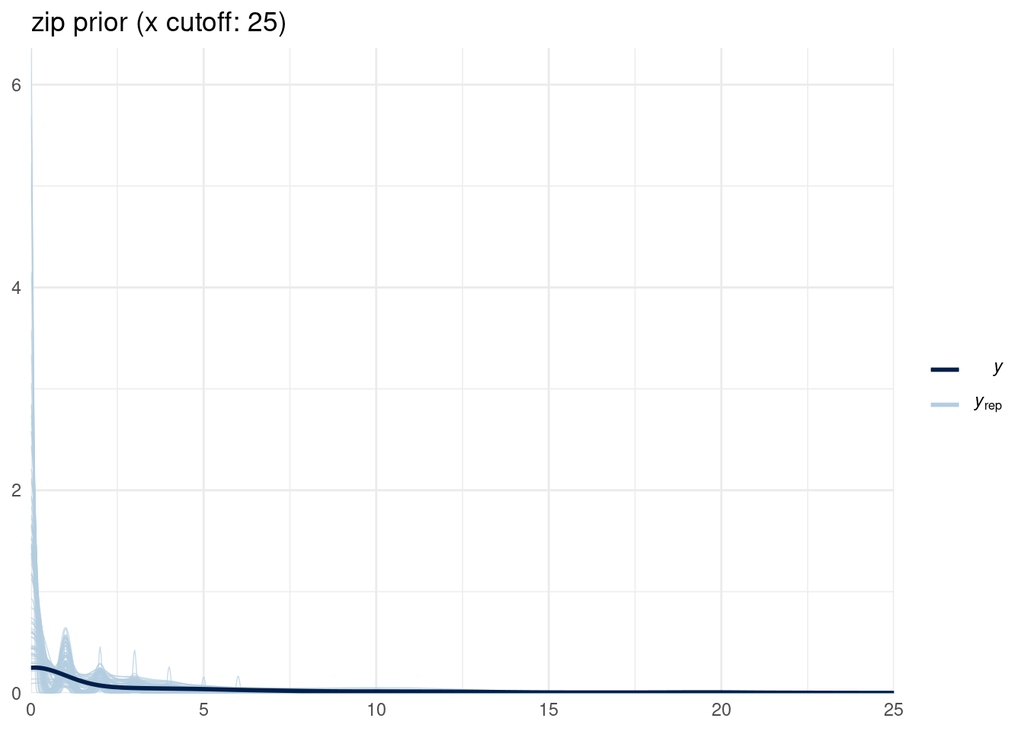

```r
prior_check(zip_prior, 100, "zip prior (x cutoff: 25)", 25)
```

## negative binomial prior

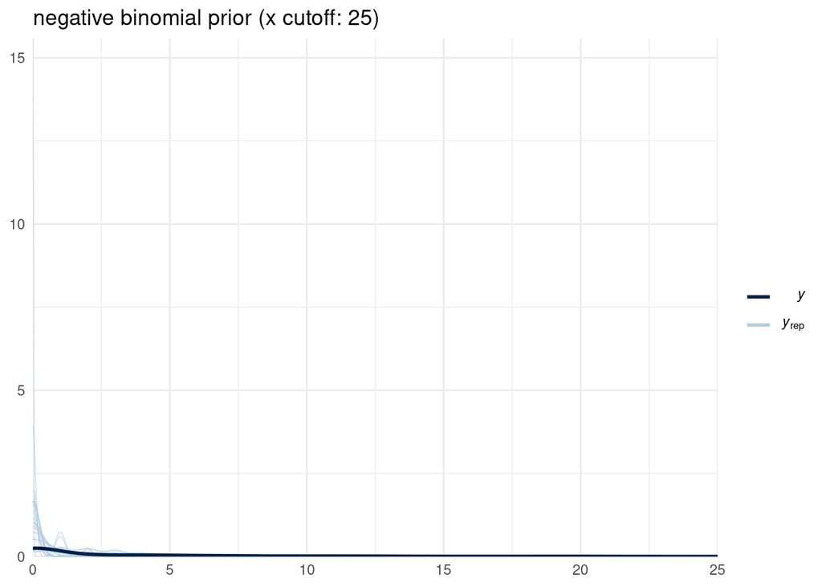

```r
prior_check(negbin_prior, 100, "negative binomial prior (x cutoff: 25)", 25)
```

## zero-inflated negative binomial prior

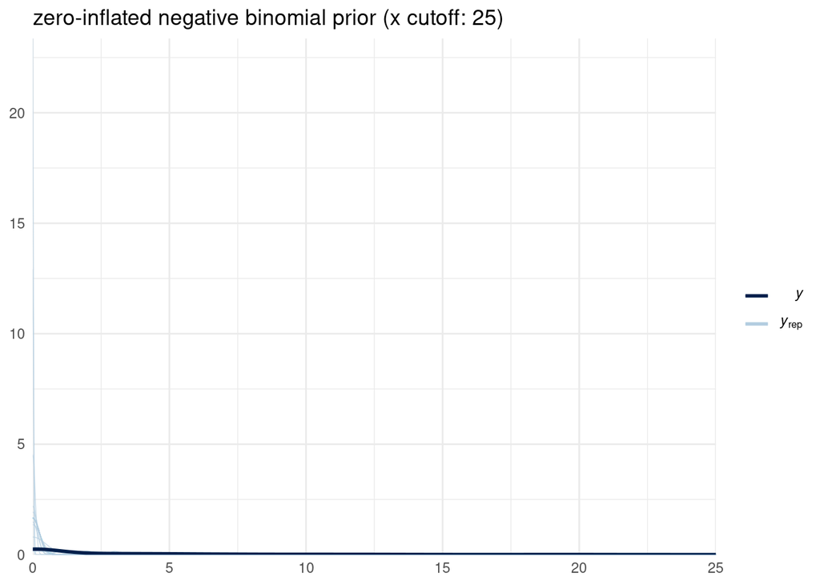

```r
prior_check(zinegbin_prior, 100, "zero-inflated negative binomial prior (x cutoff: 25)", 25)
```

# plot traces

reasonable for negative binomial and for zero-inflated negative binomial

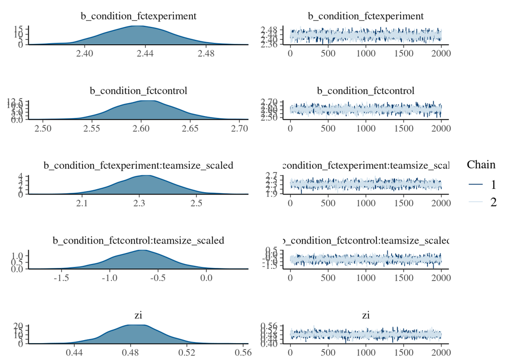

```r
plot(zip_post) # gives weird stuff
```

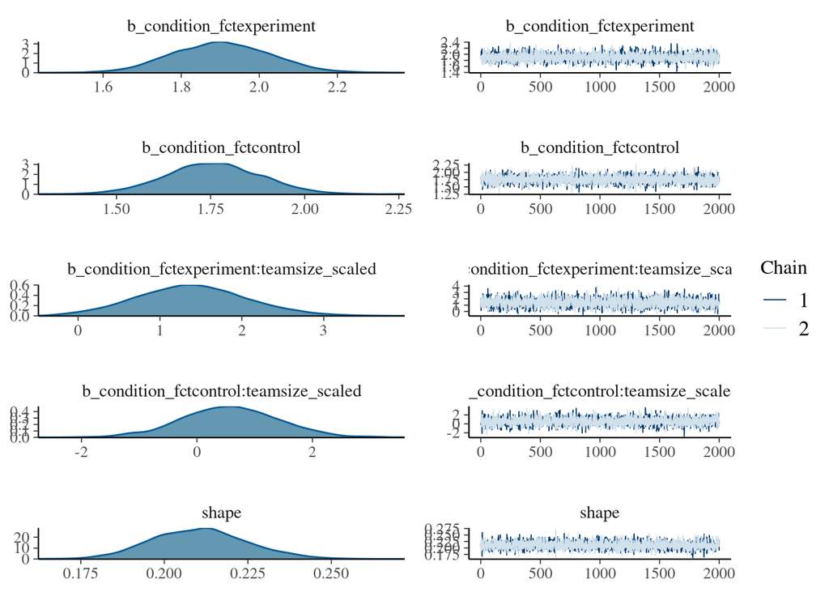

```r
plot(negbin_post) # much more reasonable
```

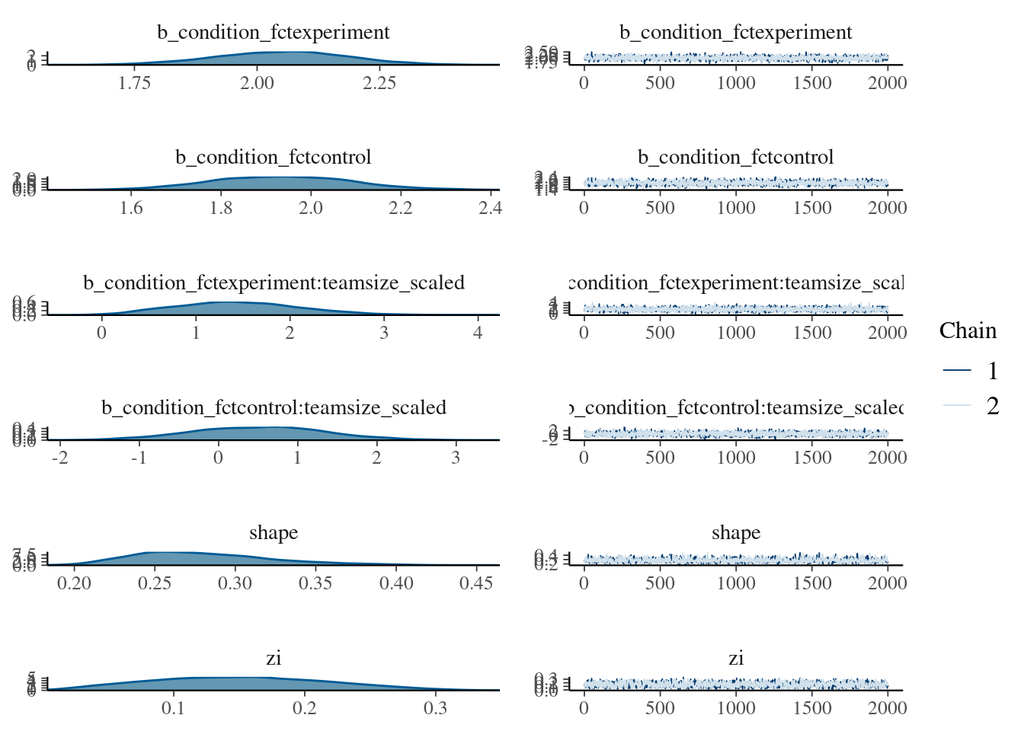

```r
plot(zinegbin_post, N = 10) # also reasonable
```

# check posterior sampling

https://mc-stan.org/bayesplot/articles/graphical-ppcs.html

```r
y <- d$c_5
y_zip <- posterior_predict(zip_post, draws = 500)
y_negbin <- posterior_predict(negbin_post, draws = 500)
y_zinegbin <- posterior_predict(zinegbin_post, draws = 500)
```

# overlay & histogram

## ZIP

we see the key issue again here… we have two distributions which is not reflective of the actual data.

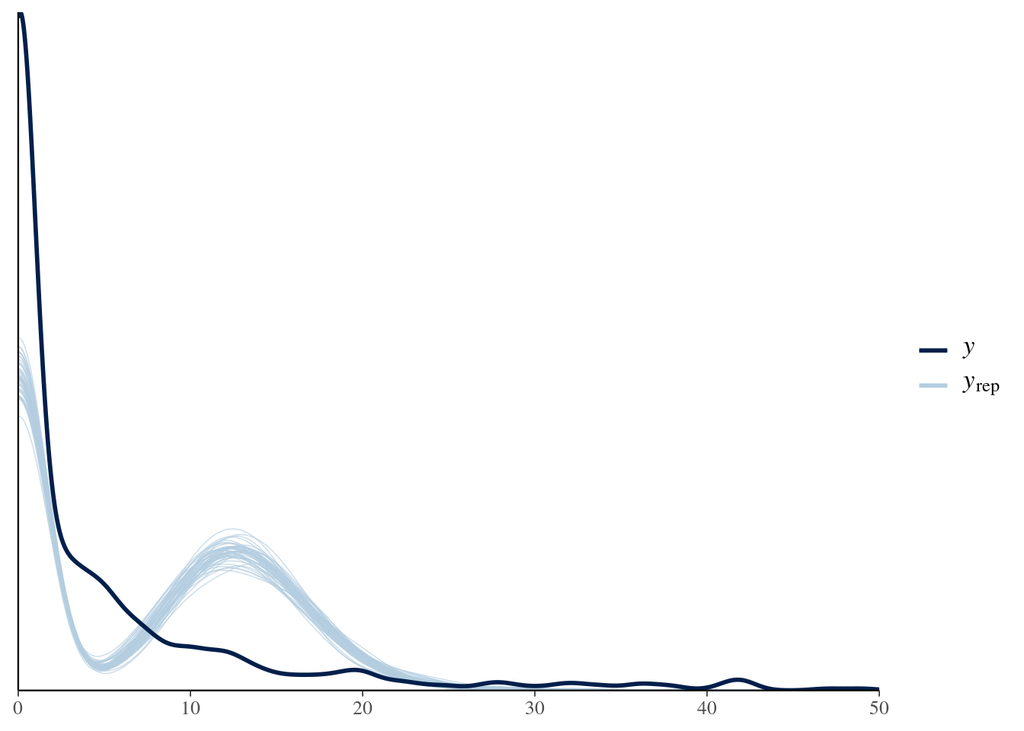

```r
ppc_dens_overlay(y, y_zip[1:50, ]) + xlim(0, 50)
```

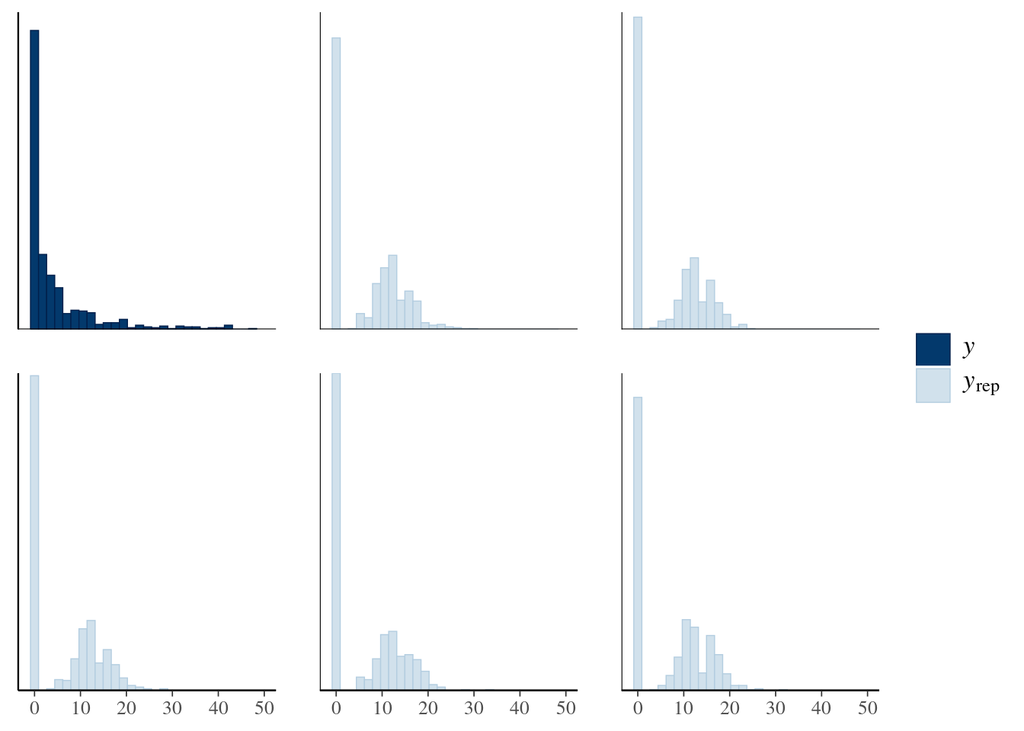

```r
ppc_hist(y, y_zip[1:5, ]) + xlim(-1, 50)
```

## negative binomial

looks really good. has a hard time figuring out the correct number of 0s.

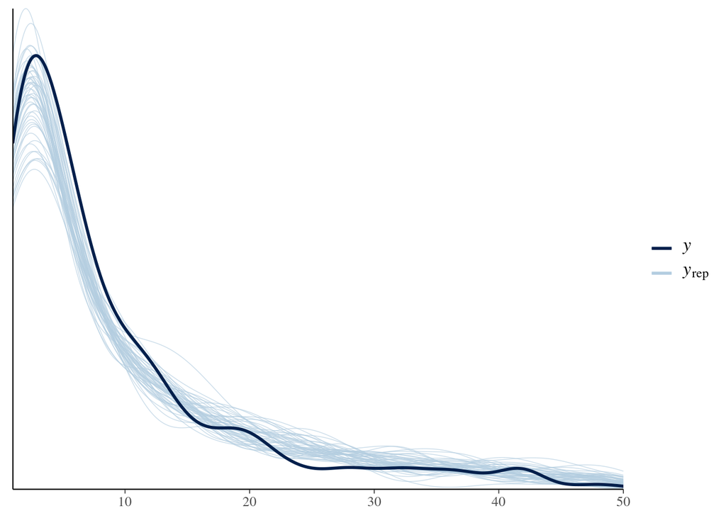

```r
ppc_dens_overlay(y, y_negbin[1:50, ]) + xlim(01, 50)
```

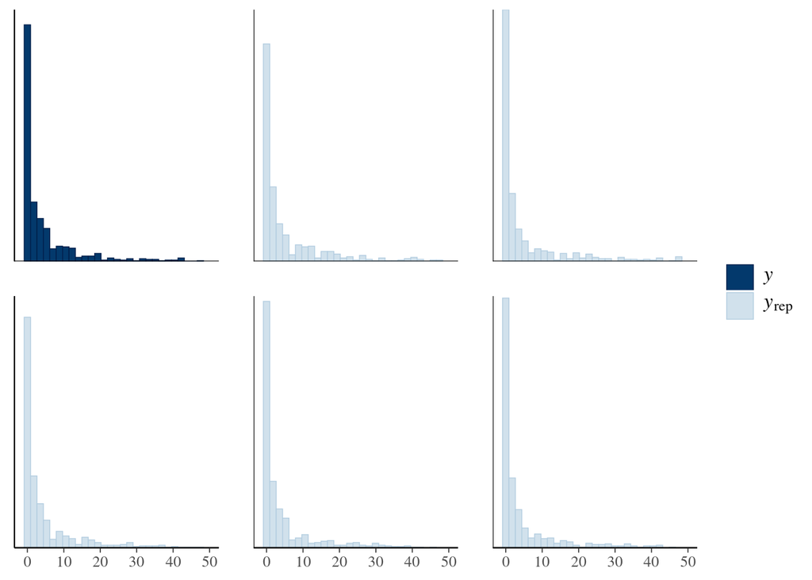

```r
ppc_hist(y, y_negbin[1:5, ]) + xlim(-1, 50)
```

## zero-inflated negative binomial

looks really good. very similar to negbin.

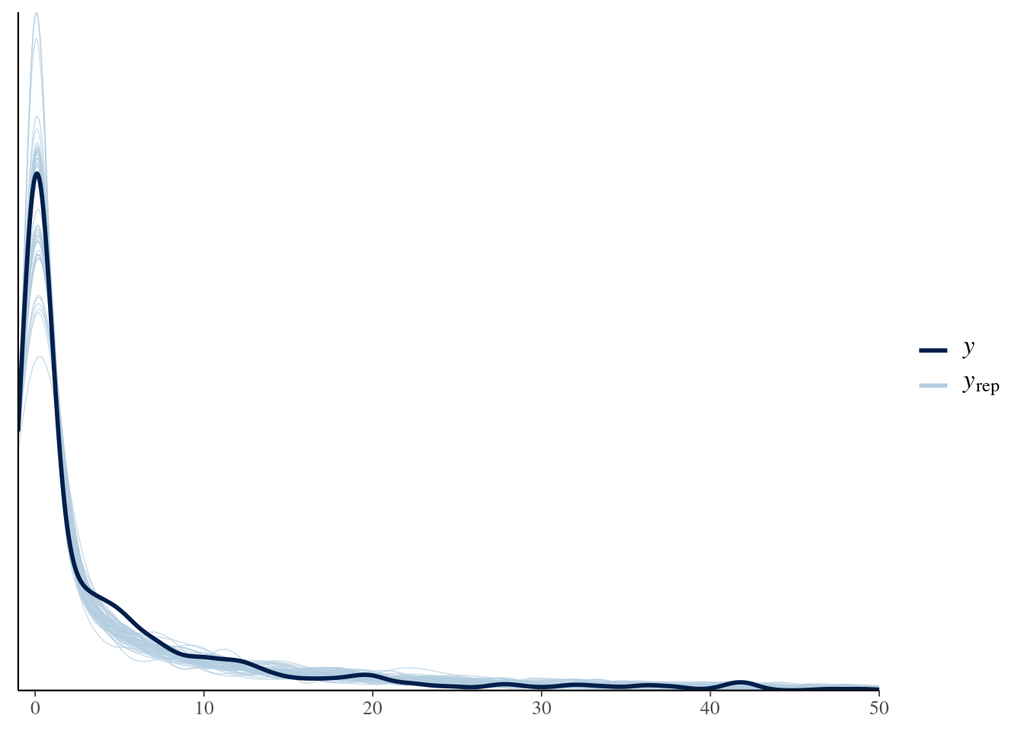

```r
ppc_dens_overlay(y, y_zinegbin[1:50, ]) + xlim(-1, 50)
```

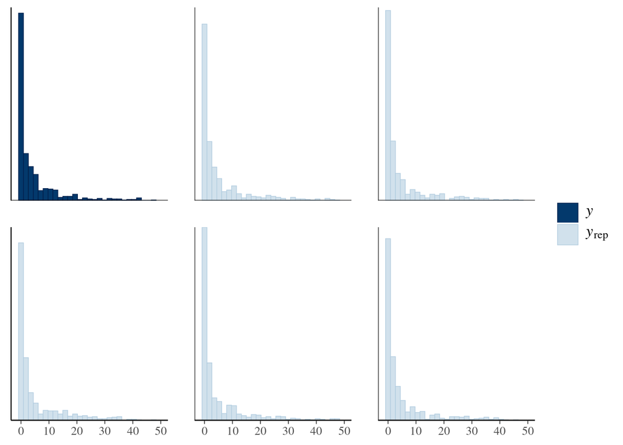

```r
ppc_hist(y, y_zinegbin[1:5, ]) + xlim(-1, 50)
```

# more PPC

## ability of models to produce zeros

All models pretty good at producing the right amount of zeros.

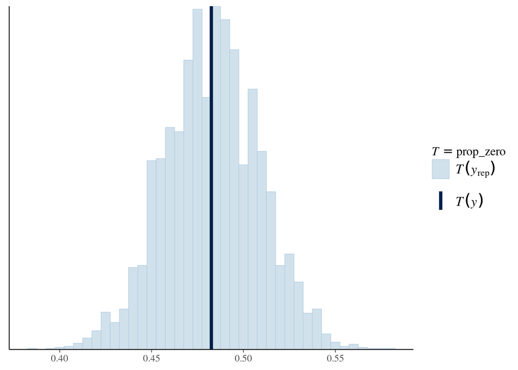

```r
prop_zero <- function(x) mean(x == 0)
ppc_stat(y, y_zip, stat = "prop_zero", binwidth = 0.005)
```

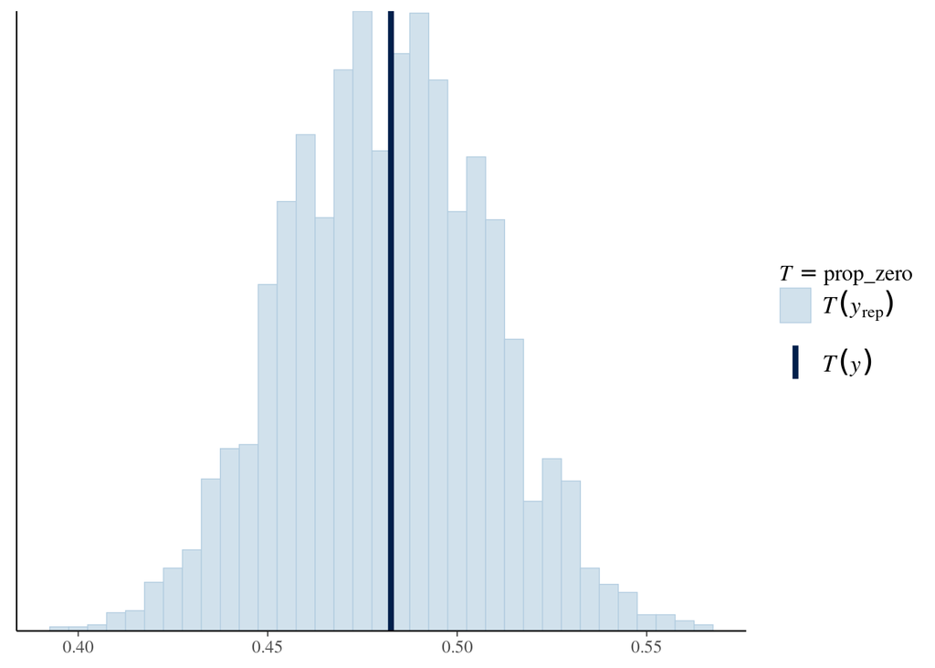

```r
ppc_stat(y, y_negbin, stat = "prop_zero", binwidth = 0.005)
```

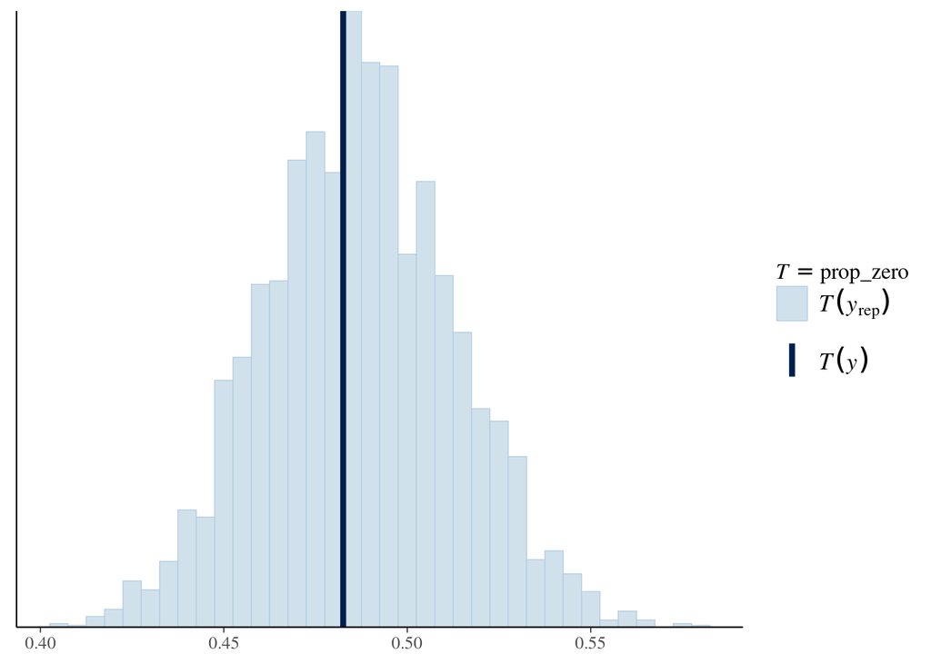

```r
ppc_stat(y, y_zinegbin, stat = "prop_zero", binwidth = 0.005)
```

## ability to generate max

Both negative binomial and zero-inflated negative binomial has some crazy outliers here, but looks pretty reasonable.

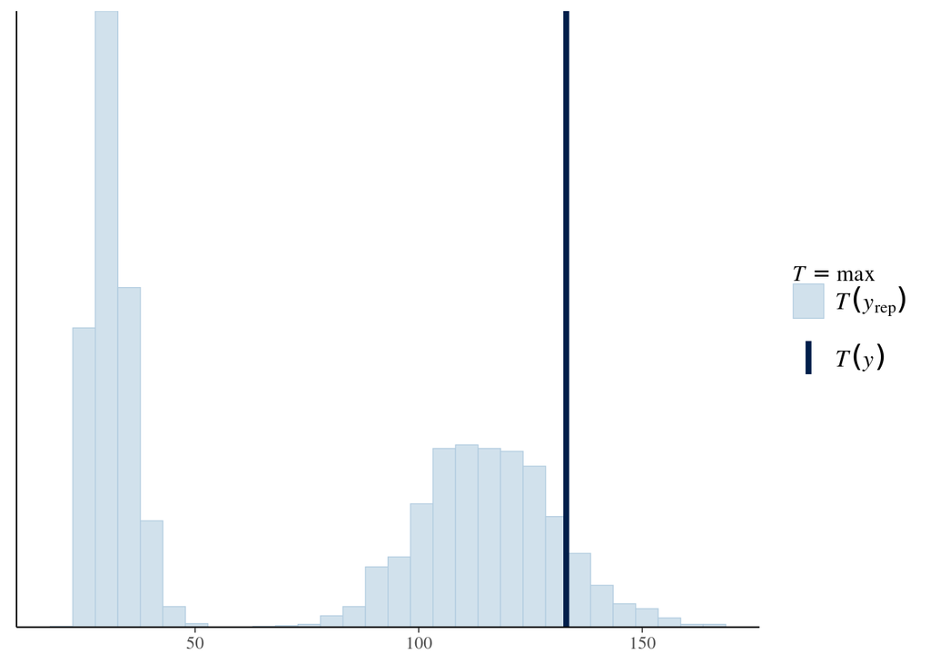

```r
ppc_stat(y, y_zip, stat = "max")
```

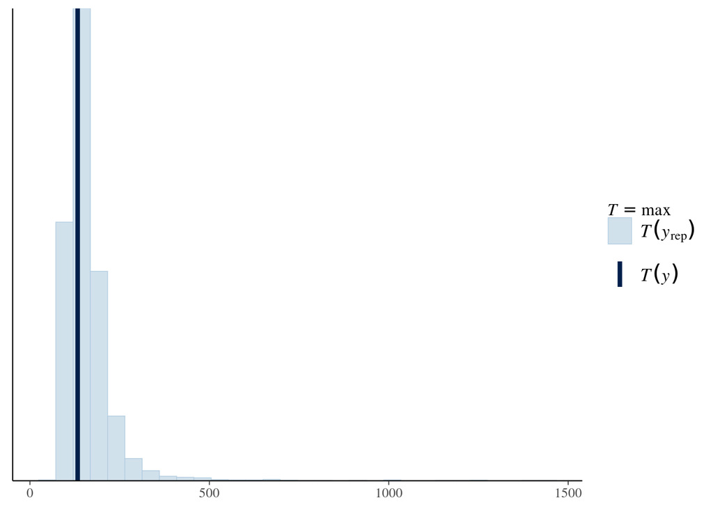

```r
ppc_stat(y, y_negbin, stat = "max")
```

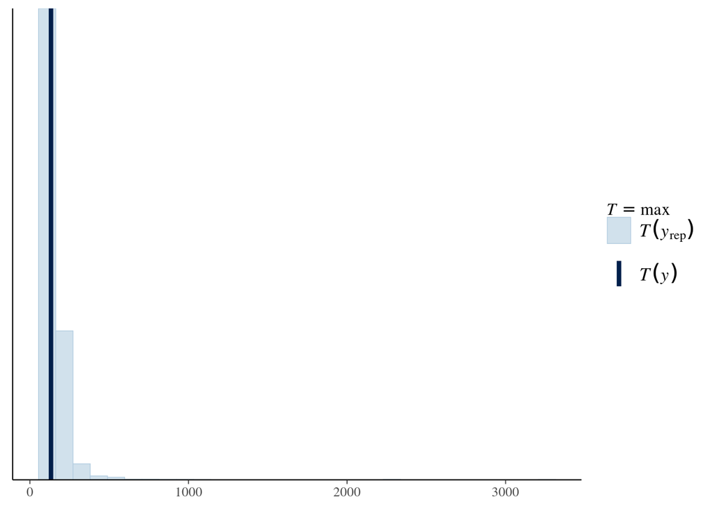

```r
ppc_stat(y, y_zinegbin, stat = "max")
```

## by group

They all predict “too much” of the same for each group (although might be good that they are more sceptical). Best model seems to be the negative binomial.

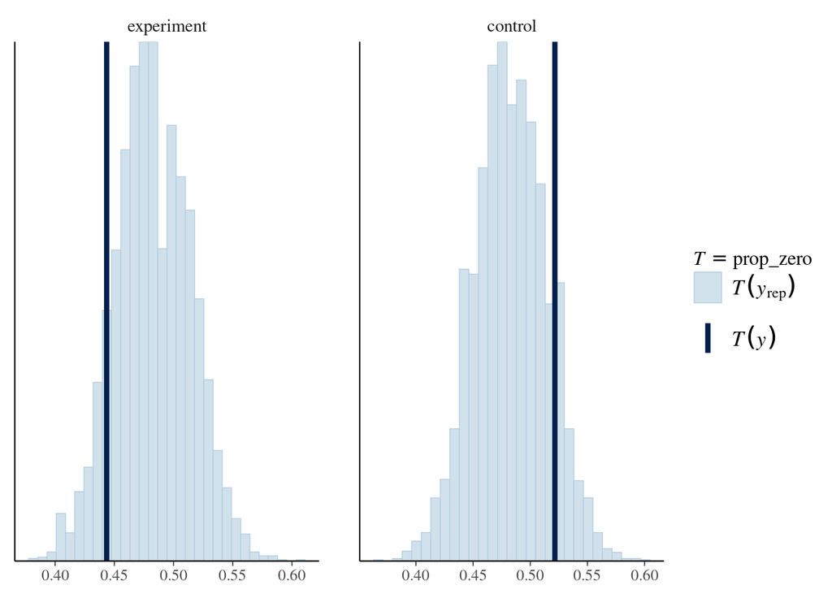

```r
ppc_stat_grouped(y, y_zip, group = d$condition_fct, stat = "prop_zero") # predicts same for groups
```

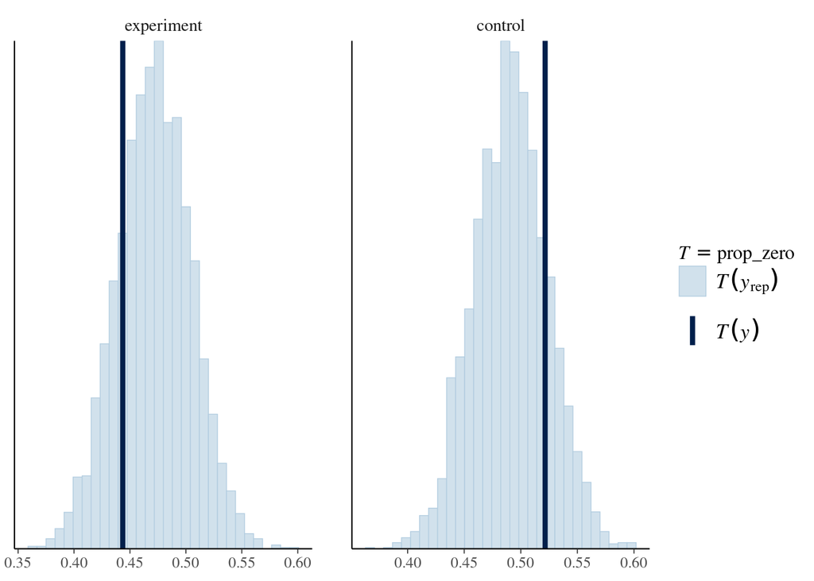

```r
ppc_stat_grouped(y, y_negbin, group = d$condition_fct, stat = "prop_zero")
```

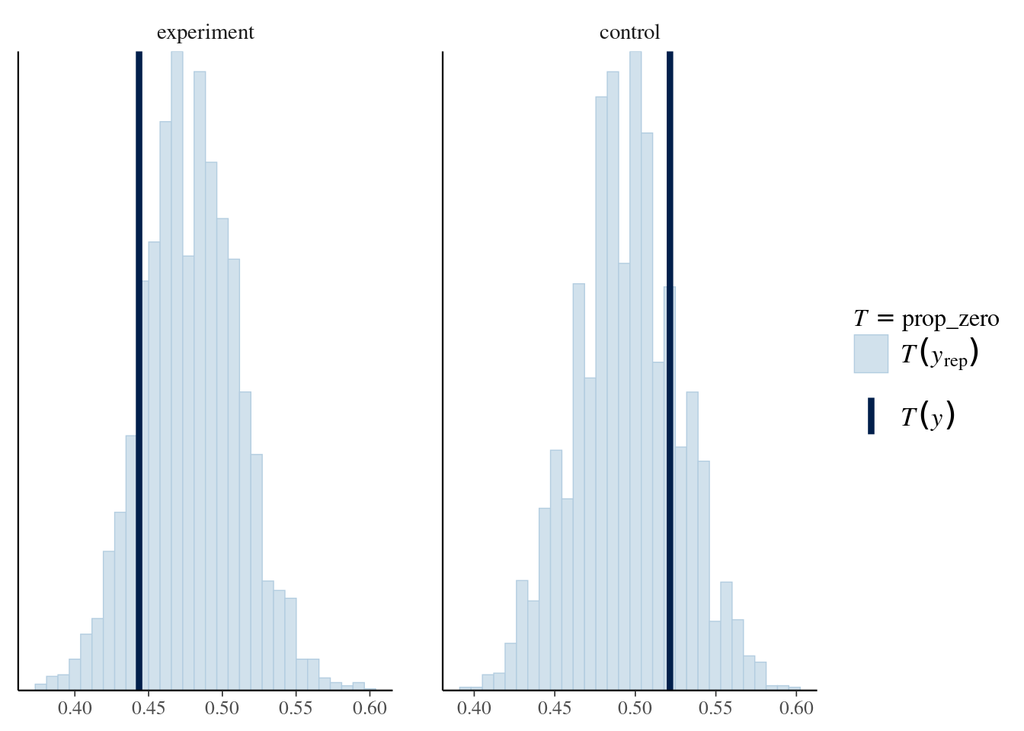

```r
ppc_stat_grouped(y, y_zinegbin, group = d$condition_fct, stat = "prop_zero")
```

# check summary

```r
summary(zip_post)
```

```
##  Family: zero_inflated_poisson
##   Links: mu = log; zi = identity
## Formula: c_5 ~ 0 + condition_fct + condition_fct:teamsize_scaled
##    Data: d (Number of observations: 744)
##   Draws: 2 chains, each with iter = 2000; warmup = 0; thin = 1;
##          total post-warmup draws = 4000
##
## Population-Level Effects:
##                                         Estimate Est.Error l-95% CI u-95% CI
## condition_fctexperiment                     2.43      0.02     2.39     2.48
## condition_fctcontrol                        2.60      0.03     2.55     2.66
## condition_fctexperiment:teamsize_scaled     2.32      0.10     2.13     2.50
## condition_fctcontrol:teamsize_scaled       -0.70      0.29    -1.27    -0.14
##                                         Rhat Bulk_ESS Tail_ESS
## condition_fctexperiment                 1.00     2731     2574
## condition_fctcontrol                    1.00     2581     2430
## condition_fctexperiment:teamsize_scaled 1.00     2647     2205
## condition_fctcontrol:teamsize_scaled    1.00     2462     1857
##
## Family Specific Parameters:
##    Estimate Est.Error l-95% CI u-95% CI Rhat Bulk_ESS Tail_ESS
## zi     0.48      0.02     0.45     0.52 1.00     3034     2210
##
## Draws were sampled using sample(hmc). For each parameter, Bulk_ESS
## and Tail_ESS are effective sample size measures, and Rhat is the potential
## scale reduction factor on split chains (at convergence, Rhat = 1).
```

```r
summary(negbin_post)
```

```
##  Family: negbinomial
##   Links: mu = log; shape = identity
## Formula: c_5 ~ 0 + condition_fct + condition_fct:teamsize_scaled
##    Data: d (Number of observations: 744)
##   Draws: 2 chains, each with iter = 2000; warmup = 0; thin = 1;
##          total post-warmup draws = 4000
##
## Population-Level Effects:
##                                         Estimate Est.Error l-95% CI u-95% CI
## condition_fctexperiment                     1.90      0.13     1.66     2.15
## condition_fctcontrol                        1.76      0.13     1.50     2.01
## condition_fctexperiment:teamsize_scaled     1.40      0.67     0.12     2.73
## condition_fctcontrol:teamsize_scaled        0.58      0.84    -1.11     2.24
##                                         Rhat Bulk_ESS Tail_ESS
## condition_fctexperiment                 1.00     2976     2613
## condition_fctcontrol                    1.00     3565     2910
## condition_fctexperiment:teamsize_scaled 1.00     3213     3128
## condition_fctcontrol:teamsize_scaled    1.00     3282     2741
##
## Family Specific Parameters:
##       Estimate Est.Error l-95% CI u-95% CI Rhat Bulk_ESS Tail_ESS
## shape     0.21      0.01     0.18     0.24 1.00     3630     2568
##
## Draws were sampled using sample(hmc). For each parameter, Bulk_ESS
## and Tail_ESS are effective sample size measures, and Rhat is the potential
## scale reduction factor on split chains (at convergence, Rhat = 1).
```

```r
summary(zinegbin_post)
```

```
##  Family: zero_inflated_negbinomial
##   Links: mu = log; shape = identity; zi = identity
## Formula: c_5 ~ 0 + condition_fct + condition_fct:teamsize_scaled
##    Data: d (Number of observations: 744)
##   Draws: 2 chains, each with iter = 2000; warmup = 0; thin = 1;
##          total post-warmup draws = 4000
##
## Population-Level Effects:
##                                         Estimate Est.Error l-95% CI u-95% CI
## condition_fctexperiment                     2.05      0.13     1.78     2.31
## condition_fctcontrol                        1.93      0.16     1.64     2.24
## condition_fctexperiment:teamsize_scaled     1.45      0.67     0.28     2.83
## condition_fctcontrol:teamsize_scaled        0.50      0.84    -1.14     2.15
##                                         Rhat Bulk_ESS Tail_ESS
## condition_fctexperiment                 1.00     1766     2577
## condition_fctcontrol                    1.00     1655     2077
## condition_fctexperiment:teamsize_scaled 1.00     2327     1981
## condition_fctcontrol:teamsize_scaled    1.00     2187     2501
##
## Family Specific Parameters:
##       Estimate Est.Error l-95% CI u-95% CI Rhat Bulk_ESS Tail_ESS
## shape     0.28      0.04     0.21     0.38 1.00     1321     2135
## zi        0.15      0.07     0.03     0.28 1.00     1254     1596
##
## Draws were sampled using sample(hmc). For each parameter, Bulk_ESS
## and Tail_ESS are effective sample size measures, and Rhat is the potential
## scale reduction factor on split chains (at convergence, Rhat = 1).
```

# plot model fit (focus on negative binomial)

## notes

### effect of interaction probably driven by the one outlier (more data and/or robust model?).

### could also consider doing something else to teamsize (e.g. log) - would make sense that it is not a linear relationship.

### also consider what McElreath does with forcing it through origin.

### add_fitted_draws() is now add_epred_draws().

https://mjskay.github.io/tidybayes/reference/add_predicted_draws.html

## fitted draws

Clear that there is a lot of weight for two large studies, where the “control” is not cited & the experiment is cited a lot. Really seems to drive the (probably spurious) effect.

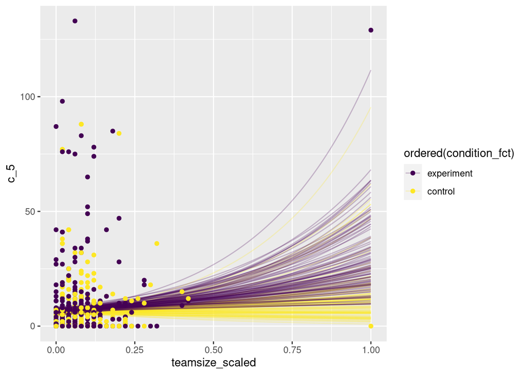

```r
# with draws
d %>%
  group_by(condition_fct) %>%
  data_grid(teamsize_scaled = seq_range(teamsize_scaled, n = 101)) %>%
  add_epred_draws(negbin_post, ndraws = 100) %>% # same as fitted
  ggplot(aes(x = teamsize_scaled, y = c_5, color = ordered(condition_fct))) +
  geom_line(aes(y = .epred, group = paste(condition_fct, .draw)), alpha = 0.25) +
  geom_point(data = d)
```

## fitted CI

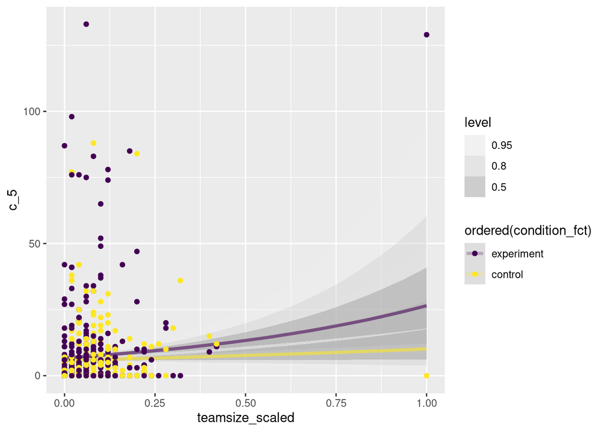

```r
d %>%
  group_by(condition_fct) %>%
  data_grid(teamsize_scaled = seq_range(teamsize_scaled, n = 101)) %>%
  add_epred_draws(negbin_post) %>% # same as fitted
  ggplot(aes(x = teamsize_scaled, y = c_5, color = ordered(condition_fct))) +
  stat_lineribbon(aes(y = .epred), .width = c(.95, .8, .5), alpha = 0.25) +
  geom_point(data = d) +
  scale_fill_brewer(palette = "Greys")
```

## predicted draws

Zero is the most common value for almost any value of teamsize & condition. Not super informative here. Perhaps more interesting with draws?

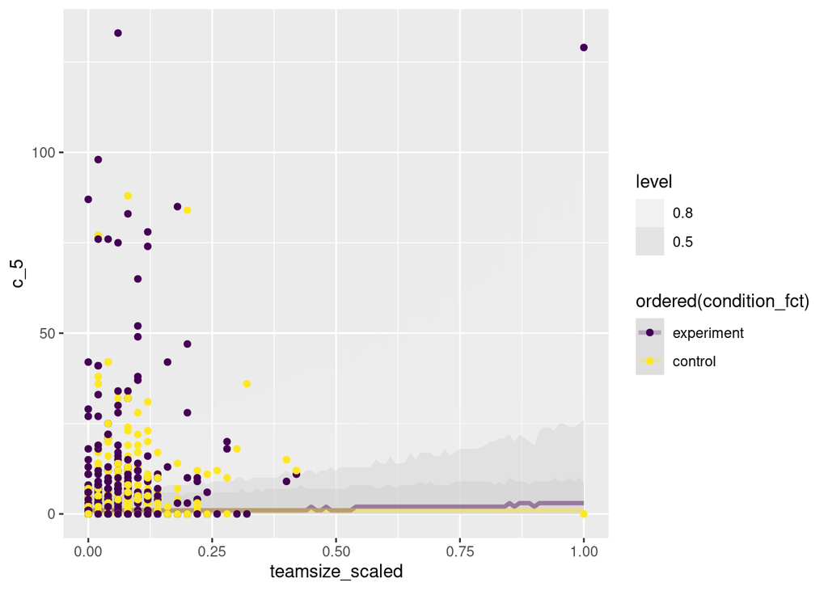

```r
# does a poor job predicting (but makes sense that 0 is always the value to predict...)
d %>%
  group_by(condition_fct) %>%
  data_grid(teamsize_scaled = seq_range(teamsize_scaled, n = 101)) %>%
  add_predicted_draws(negbin_post) %>% # same as fitted
  ggplot(aes(x = teamsize_scaled, y = c_5, color = ordered(condition_fct))) +
  stat_lineribbon(aes(y = .prediction), .width = c(.8, .5), alpha = 0.25) +
  geom_point(data = d) +
  scale_fill_brewer(palette = "Greys")
```

# HDI for parameters

```r
mcmc_hdi <- function(fit, title){

  mcmc_areas(
    fit,
    pars = c("b_condition_fctexperiment",
             "b_condition_fctcontrol",
             "b_condition_fctexperiment:teamsize_scaled",
             "b_condition_fctcontrol:teamsize_scaled"),
    prob = 0.8, # 80% intervals
    prob_outer = 0.99, # 99%
    point_est = "mean") +
    theme_minimal() +
    ggtitle(title)

}
```

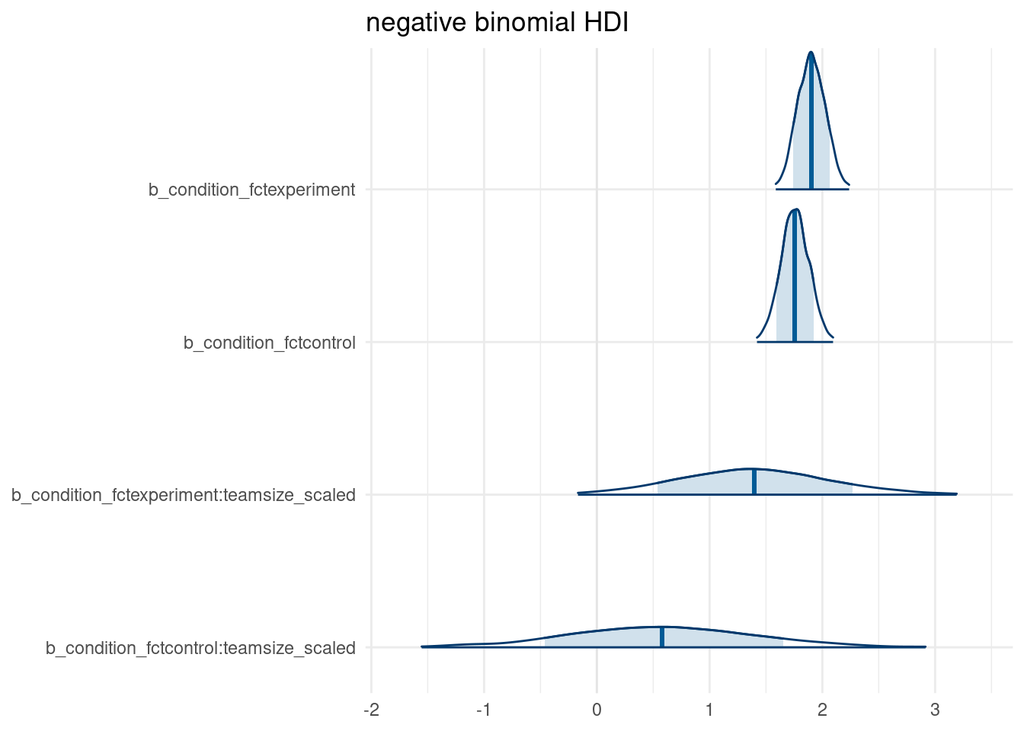

```r
mcmc_hdi(negbin_post, "negative binomial HDI")
```

# model comparison

consider criterion, i.e. waic, loo, bayes_R2 (I think the latter is for stacking weights?). best at the moment is actually the zero-inflated negative binomial, but very close to negative binomial. should probably keep both in mind moving forward (as they both looked reasonable).

```r
# add criterions
zip_post <- add_criterion(zip_post,
                          criterion = c("loo", "bayes_R2"))

negbin_post <- add_criterion(negbin_post,
                             criterion = c("loo", "bayes_R2"))

zinegbin_post <- add_criterion(zinegbin_post,
                               criterion = c("loo", "bayes_R2")) # one problematic observation.
# run loo compare
loo_compare(zip_post,
            negbin_post,
            zinegbin_post)
```

```
##               elpd_diff se_diff
## zinegbin_post     0.0       0.0
## negbin_post      -0.1       1.1
## zip_post      -2967.7     385.5
```

```r
# also uses stacking (and gives the same as pyMC3)
loo_model_weights(zip_post,
                  negbin_post,
                  zinegbin_post)
```

```
## Method: stacking
## ------
##               weight
## zip_post      0.000
## negbin_post   0.428
## zinegbin_post 0.572
```